# S1.3 — `tessellate_voronoi()`: territori di Voronoi per regione

geo_spatialtrans — report di step (binario S)

Published

October 9, 2026

```r
.libPaths("~/2025.geo_spatialtrans/renv/library/linux-ubuntu-noble/R-4.6/x86_64-pc-linux-gnu")
RES <- "../results/S1.3"; FIG <- file.path(RES, "figures")
rd <- function(f) read.csv(file.path(RES, f), check.names = FALSE)
k <- function(d, digits = 3) knitr::kable(d, digits = digits, row.names = FALSE)
V <- rd("S1.3_verdicts.csv")
```

**Obiettivo unico.** `tessellate_voronoi()` in `R/04b3_tessellate_voronoi.R` (design §5.3): dai centroidi di `seed_centroids()` ai territori cellulari, cioè Voronoi per regione ritagliato sulla regione, frammenti riassegnati e smussatura opzionale. Nuclei, preset e orchestratore restano fuori. Tutti i numeri qui sotto vengono dal codice finale (commit della chiusura), rieseguito dopo la revisione avversariale.

**Sintesi.**

- **Software (C).**
  - Sugli ingressi sintetici e avversari: 294/294 asserzioni (C-1…C-4b, C-7…C-9); 7/7 mutanti rilevati.
  - C-perf: 449 536 punti in 35.9 s e 1 076 MB, entro il budget di 150 s e 4 GB.
  - Sui 40 ROI reali C-1/C-2/C-3 passano in 40/40.
  - **C-5 (11/40) e C-6 (186/1 200) falliscono.** È un errore della mia pre-registrazione: avevo previsto un’identità con R3, ma R3 non riassegnava i frammenti ed era calcolato con `deldir`. L’attribuzione è verificata: con la regola dei frammenti di R3, 39/50 repliche tornano identiche e le altre 11 differiscono solo nel conteggio dei lati.
- **Motore.**
  - La regola pre-registrata dell’addendum C-10 non dichiara eleggibile nessuno dei due motori, e per il suo punto 4 prescrive **«S1.3 non chiusa»**. GEOS cade su K-2 (C-5) e su K-3 (15/1 800 FAIL di C-2, artefatti dell’unione GEOS); `deldir` cade su K-1, K-2, K-3 e sull’arbitro.
  - Tutte le misure che discriminano favoriscono GEOS:
    - arbitro per semipiani: 16/16 tile discordanti corretti con GEOS, 0/16 con `deldir`;
    - eventi di ripiego sugli stessi ingressi: 5 contro 705;
    - C-perf: 131 volte più veloce.
  - **Luca ha scelto GEOS e ha deciso di chiudere la sessione in deroga alla regola** (ROADMAP §6).
- **Biologia (B).** 59/62 previsioni confermate.
  - Il CV delle aree dei territori (B-2, B-3) è fuori tolleranza in A1–A5 per tutti e tre i generatori omogenei. È un limite della semina (BL-051/068), non della tassellazione.
  - Con RSA(d*) (G2) l’A6 passa tutte le metriche e l’eccentricità passa in 6/6 archetipi. Non è prova di fedeltà di forma (BL-064, BL-073).
  - La regola di default ⅔·eq_r (G3) fallisce anche in A6.
- **Controprove.**
  - CP-1 confermata: il Voronoi globale del testo del design lascia scoperta più dell’1 % dell’area nel 93.7 % delle regioni con 3–1 000 cellule.
  - CP-2 senza potenza, per un errore di disegno. Il post hoc CP-2b mostra che il check di forma vede un’anisotropia solo da 2:1.
  - CP-3: senza contenimento, Chaikin non sovrappone i territori ma li fa uscire dalla regione (9 521 territori in 29/30 ROI).
- **Scoperta laterale.** Su questi territori le operazioni di sovrapposizione di GEOS (`st_union`, `st_intersection`) danno in silenzio risultati sbagliati, mentre i predicati restano corretti. La causa: i vertici condivisi differiscono all’ultima cifra. È un rischio diretto per lo Step 2 (BL-069).
- **Verdetto:** chiusa con riserve, **in deroga** alla regola dell’addendum (decisione di Luca).

# 1. Pre-registrazione

Approvata da Luca in chat il 2026-10-08 («approvo», scelte (a) su D-S1.3.1…D-S1.3.3). File: `results/S1.3/S1.3_preregistration.md`, commit `e2f32fc`, scritto prima di qualsiasi codice. Le previsioni del check B per G1–G2 sono ricavate dai nulli di R3 con `tools/S1.3_predictions.R`, eseguito prima del codice.

**Decisioni d’apertura.**

| id | Decisione | Motivo |
| --- | --- | --- |
| D-S1.3.1 | Voronoi **per regione** | Il testo del design (Voronoi globale ritagliato sulla regione del centroide) lascia scoperte le zone di confine: CP-1 |
| D-S1.3.2 | Frammento orfano → territorio della stessa regione con il confine condiviso più lungo | Area conservata, un POLYGON per cellula. Precisata dopo la revisione: confine = tratto condiviso > 1e-6 µm, decisioni simultanee per passata, a pari merito il `cell_id` minore |
| D-S1.3.3 | Chaikin ∩ territorio originale; `n_iter = max(1, round(3·cs))` | Niente sovrapposizioni; con la formula del design cs < 1/6 non smussava |

**Addendum C-10** (`results/S1.3/S1.3_preregistration_addendum_C10.md`, commit `4ec1912`, scritto prima del confronto). Il benchmark esplorativo ha mostrato che `deldir` 2.0.4 scala come n². Luca ha chiesto un solo motore, scelto con un confronto oggettivo di cui io fissassi le metriche, e la scelta documentata. Regola: cancelli K-1…K-3 e arbitro; poi C-perf, robustezza, tempo. **Punto 4: nessun eleggibile → S1.3 non chiusa.**

**Deviazioni e correzioni dichiarate** (BL-059).

1. *Prova di fumo su I2, prima dell’addendum:* due difetti di `deldir` nella riassegnazione dei frammenti (tolleranza 1e-7 µm sulla lunghezza condivisa; aggancio se l’unione resta multiparte).
2. *Test C-4, prima del run:* per l’esagonale, «interne» = punti del reticolo con 6 vicini. Avversari: 1 centroide nelle regioni rimaste vuote.
3. *Prestazioni, prima del run:* i riquadri della riassegnazione dei frammenti sono calcolati una volta sola. A1 r1 passa da 263.2 a 33.6 s (`S1.3_dev_measurements.csv`), con gli stessi risultati.
4. *Prima del run:* arbitro per semipiani per C-10a; riferimento reale ricalcolato dal pacchetto come sensibilità del check B.
5. *Dopo il run:* corretta la regex degli avversari nello stadio C-10a sintetico.
6. *Dopo il run:* l’analisi contava come FAIL i territori multiparte del banco ROI, che la deviazione 3 ammette. Prima della correzione: ROI 25/40 per entrambi i motori, nulli GEOS 1 330/1 800, nulli `deldir` 55/90. Ora i multiparte sono ammessi solo se dovuti a orfani isolati.
7. *Post hoc:* CP-2b; copertura per punti e controllo con i predicati sui casi con C-2 fallito.
8. **Dopo la revisione avversariale.** Correzioni del codice:
   - frammenti: contatti puntiformi esclusi, decisioni simultanee, donatore escluso;
   - smussatura: per parte, riparazioni contate;
   - arbitro: certificato;
   - nuovi check C-4b e C-8c, e mutante M7.

   Correzioni dell’analisi:
   - C-5 come da testo, senza il criterio sul riassunto;
   - previsioni di G1 codificate;
   - CP-3 n.2 non valutabile;
   - robustezza sugli stessi ingressi;
   - previsioni dell’addendum codificate.

   Tutto rieseguito tranne le prestazioni. Il quadrato di C-perf non genera frammenti, quindi il percorso di codice modificato non viene esercitato e le misure restano quelle del run pre-revisione. Le uscite pre-revisione sono in `/mnt/micron/geo_spatialtrans/S1.3_prereview/` e in `results/S1.3/*_prereview.csv`. Nessun verdetto del check B è cambiato.
9. **Deroga (Luca, 2026-10-09).** La regola dell’addendum prescriveva «non chiusa»; Luca ha deciso «chiusa con riserve» e GEOS, dopo aver visto i risultati e la revisione. È una decisione del responsabile, non un esito della regola.

# 2. Check C — correttezza software

```r
cc <- V[V$section %in% c("C", "C10") & !V$id %in% c("C-10c", "scelta", "previsione"), c("id", "model", "metric", "value", "threshold", "outcome")]
names(cc) <- c("check", "motore", "metrica", "valore", "soglia", "esito"); k(cc)
```

| check | motore | metrica | valore | soglia | esito |
| --- | --- | --- | --- | --- | --- |
| C-1 | geos | asserzioni PASS | 26/26 | 100 % | PASS |
| C-2 | geos | asserzioni PASS | 52/52 | 100 % | PASS |
| C-3 | geos | asserzioni PASS | 52/52 | 100 % | PASS |
| C-7 | geos | asserzioni PASS | 130/130 | 100 % | PASS |
| C-8 | geos | asserzioni PASS | 15/15 | 100 % | PASS |
| C-4 | geos | asserzioni PASS | 12/12 | 100 % | PASS |
| C-9 | geos | asserzioni PASS | 7/7 | 100 % | PASS |
| C-1 | deldir | asserzioni PASS | 26/26 | 100 % | PASS |
| C-2 | deldir | asserzioni PASS | 48/52 | 100 % | FAIL |
| C-3 | deldir | asserzioni PASS | 52/52 | 100 % | PASS |
| C-7 | deldir | asserzioni PASS | 130/130 | 100 % | PASS |
| C-8 | deldir | asserzioni PASS | 15/15 | 100 % | PASS |
| C-4 | deldir | asserzioni PASS | 12/12 | 100 % | PASS |
| C-9 | deldir | asserzioni PASS | 7/7 | 100 % | PASS |
| mutanti | geos | rilevati | 7/7 | 7/7 | PASS |
| C-5 | geos | ROI identici a R3 (40) | 11/40; max rel area interne 7.72e-01 | 40/40 | FAIL |
| C-1..3 ROI | geos | ROI con C-1/C-2/C-3 PASS | 40/40; max C-1 6.88e-15 | 40/40 | PASS |
| C-5 | deldir | ROI identici a R3 (40) | 12/40; max rel area interne 7.72e-01 | 40/40 | FAIL |
| C-1..3 ROI | deldir | ROI con C-1/C-2/C-3 PASS | 35/40; max C-1 2.19e-10 | 40/40 | FAIL |
| C-6 | geos | repliche identiche a R3 | 186/1200 (attese 1200); max rel 3.64e-01 | 1200/1200 | FAIL |
| C-1..3 nulli | geos | tassellazioni PASS | 1785/1800 | 1800/1800 | FAIL |
| C-1..3 nulli | deldir | tassellazioni PASS (replica 1) | 76/90 | 90/90 | FAIL |
| arbitro | semipiani | tile discordanti: corretti geos / deldir | 16: 16 / 0 (limitati 16) | - | INFO |
| C-10a | geos vs deldir | insiemi concordi (40 reali + 90 nulli + 26 sintetici/avversari) | 146/156; max rel area 1.71e-06 | 100 % | FAIL |
| C-perf | geos | 449 536 punti: s, MB | 35.9 s, 1076 MB (ok) | <= 150 s, <= 4096 MB | PASS |
| C-perf | deldir | 449 536 punti: s, MB | 4690.7 s, 8958 MB (ok) | <= 150 s, <= 4096 MB | FAIL |
| C-2 copertura (post hoc) | geos | punti coperti 0/1/≥2; coppie sovrapposte; area | 0/2500000/0; 28 coppie; 3.40e+02 um2 (25 casi) | 0 / tutti / 0 | PASS |
| C-2 copertura (post hoc) | deldir | punti coperti 0/1/≥2; coppie sovrapposte; area | 0/2900000/0; 28922 coppie; 3.66e+01 um2 (29 casi) | 0 / tutti / 0 | PASS |

```r
k(rd("S1.3_mutants.csv"))
```

| mutant | target | n_fail_target | detected |
| --- | --- | --- | --- |
| M1 | C-3 | 17 | TRUE |
| M2 | C-1 | 26 | TRUE |
| M3 | C-1 | 19 | TRUE |
| M4 | C-7 | 19 | TRUE |
| M5 | C-1/C-4 | 20 | TRUE |
| M6 | C-3 | 36 | TRUE |
| M7 | C-4 | 1 | TRUE |

**Lettura.**

- **Ingressi sintetici e avversari.** Con GEOS ogni asserzione passa. C-4b controlla la regola dei frammenti su geometrie costruite a mano: confine 2 contro 1, contatto in un solo punto, catena di orfani valutata in due ordini. C-8c controlla che, rietichettando i `cell_id`, il territorio segua il punto. M7 (orfano al confine più corto) è rilevato da C-4b. Avvertenza: C-8 «permutazione» passa per costruzione, perché la funzione ordina i centroidi.
- **`deldir` fallisce C-2 in 4 asserzioni su I4.** I suoi lati condivisi non coincidono all’ultima cifra: 639 coppie di tile hanno interni sovrapposti per strisce di circa 1e-12 µm², contro 1 coppia con GEOS. Su questa geometria non annodata l’unione GEOS perde una cella intera (52.4 µm², `S1.3_dev_measurements.csv`).
- **C-5 e C-6: errore della pre-registrazione (BL-074).** Avevo scritto «le interne sono identiche a R3». Ma il territorio che *riceve* un frammento può essere interno, e allora la sua area cresce. La verifica diretta (`S1.3_review_c6_attribution.csv`): 50 repliche (40 con frammenti, più le 10 senza frammenti ma non identiche) ritassellate con la regola di R3 tornano identiche a R3 in 39/50 casi; le altre 11 differiscono solo nella media o nella varianza del numero di lati. Con il codice di R3 (`deldir`) le 50 tornano identiche in 50/50. Il residuo sulle celle senza frammenti dei ROI reali (A1 r5) nasce dalla dipendenza di `deldir` dal riquadro di calcolo: 152 tile cambiano area fra due riquadri (`S1.3_review_A1r5_deldir_rw.csv`), mentre GEOS coincide con R3 e con l’arbitro.
- **C-2 sui nulli GEOS (15/1 800 FAIL): falso allarme dello strumento.** Su 2.5 milioni di punti, 0 sono scoperti e 0 coperti due volte. La risoluzione è di circa 9 µm² per punto, sufficiente per le perdite osservate (fino a 1 359 µm²) ma non per strisce di 1e-12 µm². Delle 28 coppie con interni sovrapposti, 27 hanno sovrapposizione ≤ 9e-13 µm². L’unica coppia «da 340 µm²» (A3 r3 CSR rep 3, celle 766 e 1987) è un poligono sbagliato restituito da `st_intersection`: dei 2 000 punti campionati in quell’intersezione, tutti stanno in una sola cella. Il revisore ha confermato in aritmetica razionale un’intersezione vera di 1.2e-14 µm². Lo stesso vale per la coppia `deldir` da 36.6 µm² (0/2 000 punti in entrambe). → BL-069, BL-070.

```r
cv <- rd("S1.3_c2_coverage.csv"); k(aggregate(cbind(casi = 1, punti_0 = cov0, punti_1 = cov1, punti_2 = cov2, coppie = n_pairs, area_coppie = ov_area) ~ set + engine, cv, sum), 3)
```

| set | engine | casi | punti_0 | punti_1 | punti_2 | coppie | area_coppie |
| --- | --- | --- | --- | --- | --- | --- | --- |
| null | deldir | 14 | 0 | 1400000 | 0 | 19672 | 0.000 |
| real | deldir | 5 | 0 | 500000 | 0 | 7770 | 0.000 |
| syn | deldir | 10 | 0 | 1000000 | 0 | 1480 | 36.591 |
| null | geos | 15 | 0 | 1500000 | 0 | 18 | 340.427 |
| syn | geos | 10 | 0 | 1000000 | 0 | 10 | 0.000 |

```r
k(rd("S1.3_c2_overlap_pairs_check.csv")[, c("case", "i", "j", "area", "n_pts", "in_both", "in_i", "in_j")], 3)
```

| case | i | j | area | n_pts | in_both | in_i | in_j |
| --- | --- | --- | --- | --- | --- | --- | --- |
| A1 r2 RSArule 10 | 3926 | 4299 | 0.000 | NA | NA | NA | NA |
| A2 r5 CSR 2 | 2612 | 5785 | 0.000 | NA | NA | NA | NA |
| A3 r1 RSArule 12 | 1024 | 2844 | 0.000 | NA | NA | NA | NA |
| A3 r2 RSA 10 | 1393 | 1939 | 0.000 | NA | NA | NA | NA |
| A3 r2 RSA 10 | 1449 | 2873 | 0.000 | NA | NA | NA | NA |
| A3 r2 RSA 10 | 2137 | 2488 | 0.000 | NA | NA | NA | NA |
| A3 r3 CSR 3 | 766 | 1987 | 340.427 | 2000 | 0 | 2000 | 0 |
| A3 r4 RSA 14 | 1844 | 2217 | 0.000 | NA | NA | NA | NA |
| A4 f1 RSArule 20 | 7986 | 21555 | 0.000 | NA | NA | NA | NA |
| A4 f1 RSArule 20 | 18899 | 19474 | 0.000 | NA | NA | NA | NA |
| A4 p3 CSR 15 | 4474 | 17739 | 0.000 | NA | NA | NA | NA |
| A4 p3 CSR 15 | 7665 | 21319 | 0.000 | NA | NA | NA | NA |
| A4 p3 CSR 15 | 12903 | 17170 | 0.000 | NA | NA | NA | NA |
| A4 p3 RSArule 2 | 14040 | 17651 | 0.000 | NA | NA | NA | NA |
| A5 r1 RSA 17 | 33 | 232 | 0.000 | NA | NA | NA | NA |
| A6 r3 RSArule 13 | 71 | 1032 | 0.000 | NA | NA | NA | NA |
| A6 r3 RSArule 13 | 151 | 748 | 0.000 | NA | NA | NA | NA |
| A6 r3 RSArule 13 | 937 | 979 | 0.000 | NA | NA | NA | NA |

```r
k(rd("S1.3_review_deldir_pair_check.csv"), 3)
```

| case | i | j | area | n_pts | in_both |
| --- | --- | --- | --- | --- | --- |
| I4_s3_reg5 | 394 | 1887 | 36.591 | 2000 | 0 |

## Confronto dei motori (C-10)

```r
e <- rd("S1.3_engine_choice.csv"); k(e[, c("engine", "K1", "K2", "K3", "K_arb", "eligible", "cperf", "slope", "robustness_events")], 2)
```

| engine | K1 | K2 | K3 | K_arb | eligible | cperf | slope | robustness_events |
| --- | --- | --- | --- | --- | --- | --- | --- | --- |
| geos | TRUE | FALSE | FALSE | TRUE | FALSE | TRUE | 0.93 | 5 |
| deldir | FALSE | FALSE | FALSE | FALSE | FALSE | FALSE | 1.70 | 705 |

```r
k(V[V$id == "previsione", c("metric", "value", "outcome", "prediction", "confirmed")])
```

| metric | value | outcome | prediction | confirmed |
| --- | --- | --- | --- | --- |
| entrambi eleggibili |  | FAIL | PASS | FALSE |
| robustezza: deldir > 0 eventi, GEOS 0 (stessi ingressi) | geos 5, deldir 705 | FAIL | PASS | FALSE |
| GEOS >= 20x piu’ veloce a 8e4 | 26.7x | PASS | PASS | TRUE |
| deldir fallisce C-perf, GEOS lo passa | geos TRUE, deldir FALSE | PASS | PASS | TRUE |
| rapporto dei tempi a 449 536 punti | 130.7x | INFO | NA | NA |

```r
k(rd("S1.3_perf.csv"), 3)
```

| backend | n | elapsed_s | c2_rel | n_multipart | n_snapped | max_rss_mb | status |
| --- | --- | --- | --- | --- | --- | --- | --- |
| geos | 10000 | 1.0 | 0 | 0 | 0 | 155 | ok |
| geos | 20000 | 1.8 | 0 | 0 | 0 | 183 | ok |
| geos | 40000 | 3.3 | 0 | 0 | 0 | 237 | ok |
| geos | 80000 | 6.4 | 0 | 0 | 0 | 332 | ok |
| geos | 160000 | 13.1 | 0 | 0 | 0 | 472 | ok |
| geos | 449536 | 35.9 | 0 | 0 | 0 | 1076 | ok |
| deldir | 10000 | 5.7 | 0 | 0 | 0 | 199 | ok |
| deldir | 20000 | 16.0 | 0 | 0 | 0 | 262 | ok |
| deldir | 40000 | 49.3 | 0 | 0 | 0 | 450 | ok |
| deldir | 80000 | 171.0 | 0 | 0 | 0 | 911 | ok |
| deldir | 160000 | 628.5 | 0 | 0 | 0 | 2097 | ok |
| deldir | 449536 | 4690.7 | 0 | 0 | 0 | 8958 | ok |

```r
k(rd("S1.3_c10a_arbitration.csv")[, c("set", "archetype", "roi_id", "model", "cell", "a_geos", "a_deldir", "a_hp", "ns_geos", "ns_deldir", "ns_hp", "min_edge", "geos_ok", "deldir_ok")], 8)
```

| set | archetype | roi_id | model | cell | a_geos | a_deldir | a_hp | ns_geos | ns_deldir | ns_hp | min_edge | geos_ok | deldir_ok |
| --- | --- | --- | --- | --- | --- | --- | --- | --- | --- | --- | --- | --- | --- |
| real | A1 | r5 | cellpose_rgb | 1923 | 32.29828 | 32.29825 | 32.29828 | 7 | 6 | 7 | 1.939e-05 | TRUE | FALSE |
| real | A1 | r5 | cellpose_rgb | 1979 | 30.49228 | 30.49224 | 30.49228 | 6 | 5 | 6 | 1.939e-05 | TRUE | FALSE |
| real | A1 | r5 | cellpose_rgb | 7107 | 32.62558 | 32.62554 | 32.62558 | 6 | 5 | 6 | 2.320e-05 | TRUE | FALSE |
| real | A1 | r5 | cellpose_rgb | 7158 | 25.02070 | 25.02065 | 25.02070 | 6 | 5 | 6 | 2.320e-05 | TRUE | FALSE |
| real | A4 | p3 | spaceranger | 18665 | 52.98981 | 52.98981 | 52.98981 | 7 | 6 | 7 | 2.380e-06 | TRUE | FALSE |
| real | A4 | p3 | spaceranger | 19186 | 70.38591 | 70.38590 | 70.38591 | 8 | 7 | 8 | 2.380e-06 | TRUE | FALSE |
| null | A1 | r1 | CSR | 3523 | 18.32144 | 18.32142 | 18.32144 | 6 | 5 | 6 | 7.670e-06 | TRUE | FALSE |
| null | A1 | r1 | CSR | 4691 | 127.38094 | 127.38094 | 127.38094 | 8 | 7 | 8 | 7.670e-06 | TRUE | FALSE |
| null | A3 | r1 | RSArule | 945 | 224.40621 | 224.40618 | 224.40621 | 6 | 5 | 6 | 1.096e-05 | TRUE | FALSE |
| null | A3 | r1 | RSArule | 1242 | 284.65530 | 284.65527 | 284.65530 | 8 | 7 | 8 | 1.096e-05 | TRUE | FALSE |
| null | A3 | r3 | RSA | 2755 | 146.72785 | 146.72778 | 146.72785 | 5 | 4 | 5 | 1.167e-05 | TRUE | FALSE |
| null | A3 | r3 | RSA | 3975 | 215.89934 | 215.89925 | 215.89934 | 8 | 7 | 8 | 1.167e-05 | TRUE | FALSE |
| null | A4 | p3 | RSA | 15144 | 30.89508 | 30.89506 | 30.89508 | 6 | 5 | 6 | 7.410e-06 | TRUE | FALSE |
| null | A4 | p3 | RSA | 16469 | 29.77587 | 29.77587 | 29.77587 | 7 | 6 | 7 | 7.410e-06 | TRUE | FALSE |
| null | A4 | p3 | RSArule | 8473 | 28.72931 | 28.72929 | 28.72931 | 6 | 5 | 6 | 5.270e-06 | TRUE | FALSE |
| null | A4 | p3 | RSArule | 13494 | 34.10668 | 34.10668 | 34.10668 | 7 | 6 | 7 | 5.270e-06 | TRUE | FALSE |

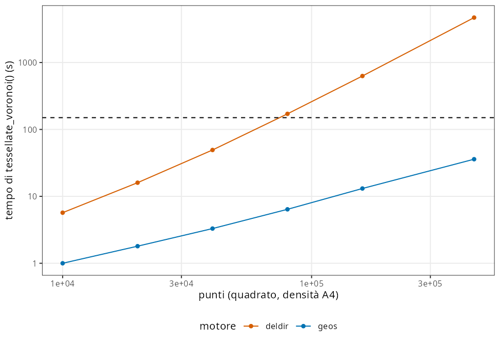

Tempo di `tessellate_voronoi()` per i due motori (quadrato, densità A4). Linea tratteggiata: budget C-perf.

**Lettura.**

- **Concordanza.** C-10a è FAIL (146/156 insiemi concordi), contro la previsione PASS. Le discordanze stanno tutte su configurazioni quasi cocircolari con un lato cortissimo, che `deldir` elimina. L’arbitro per semipiani è indipendente da entrambe le librerie, ed è stato corretto dopo la revisione con un certificato sulla distanza; contando come lati solo i segmenti > 1e-9 µm (BL-075), dà ragione a GEOS in 16/16 tile discordanti. La reimplementazione Qhull del revisore conferma le aree GEOS in 26/26 righe della versione pre-revisione.
- **Robustezza sugli stessi ingressi** (test, 40 ROI reali, replica 1 dei 90 nulli): 5 eventi di ripiego con GEOS, tutti agganci riusciti; 705 con `deldir`. La previsione «GEOS 0» è smentita.
- **Prestazioni:** a 449 536 punti GEOS è 130.7 volte più veloce (35.9 s contro 4 690.7 s; `deldir` sfora il budget di 31 volte). Esponenti di scala 0.93 e 1.70.
- **Regola dell’addendum.** Nessun eleggibile → «non chiusa». GEOS cade su K-2 (C-5: errore di pre-registrazione, comune ai due motori) e su K-3 (C-2 misurato con l’unione: 15/1 800 tassellazioni GEOS, tutte falsi allarmi; 14/90 con `deldir` sulla sola replica 1). Neppure un C-5 ristretto alle celle senza frammenti sarebbe passato: gli scarti residui contro R3 di 1.2e-6 sono errori di `deldir` dentro R3.
- **Decisione di Luca (2026-10-08/09): GEOS**, in deroga alla regola.

# 3. Check B — plausibilità biologica (A1–A6)

30 ROI, stessa maschera e stessa regola d’interna di R3. G1 = CSR, G2 = RSA(d*), G3 = RSA con la regola di default ⅔·eq_r; 20 repliche per ROI. Verdetto per archetipo: PASS se la condizione vale in ≥ 4/5 ROI. Riferimento pre-registrato: tabelle di R3 (B-055…B-090).

```r
b <- V[V$section == "B" & V$id %in% c("B1", "B2", "B3", "B4"), ]
w <- reshape(b[, c("id", "archetype", "model", "outcome")], idvar = c("archetype", "model"), timevar = "id", direction = "wide")
names(w) <- sub("outcome.", "", names(w)); k(w[order(w$model, w$archetype), ])
```

| archetype | model | B1 | B2 | B3 | B4 |
| --- | --- | --- | --- | --- | --- |
| A1 | G1 | FAIL | FAIL | FAIL | PASS |
| A2 | G1 | FAIL | FAIL | FAIL | PASS |
| A3 | G1 | FAIL | FAIL | FAIL | PASS |
| A4 | G1 | PASS | FAIL | FAIL | FAIL |
| A5 | G1 | FAIL | FAIL | FAIL | PASS |
| A6 | G1 | PASS | PASS | PASS | PASS |
| A1 | G2 | FAIL | FAIL | FAIL | PASS |
| A2 | G2 | FAIL | FAIL | FAIL | PASS |
| A3 | G2 | FAIL | FAIL | FAIL | PASS |
| A4 | G2 | FAIL | FAIL | FAIL | PASS |
| A5 | G2 | FAIL | FAIL | FAIL | PASS |
| A6 | G2 | PASS | PASS | PASS | PASS |
| A1 | G3 | FAIL | FAIL | FAIL | PASS |
| A2 | G3 | FAIL | FAIL | FAIL | PASS |
| A3 | G3 | FAIL | FAIL | FAIL | PASS |
| A4 | G3 | PASS | FAIL | FAIL | FAIL |
| A5 | G3 | FAIL | FAIL | FAIL | PASS |
| A6 | G3 | FAIL | FAIL | FAIL | PASS |

```r
pr <- V[V$section == "B" & !is.na(V$prediction) & V$prediction != "", c("id", "archetype", "model", "value", "outcome", "prediction", "confirmed")]
cat(sprintf("Previsioni: %d, confermate %d\n", nrow(pr), sum(pr$confirmed == "TRUE"))); k(pr[pr$confirmed != "TRUE", ])
```

```
Previsioni: 62, confermate 59
```

| id | archetype | model | value | outcome | prediction | confirmed |
| --- | --- | --- | --- | --- | --- | --- |
| B1 | A5 | G1 | 3/5 ROI; -0.040..+0.092 | FAIL | PASS | FALSE |
| B4 | A5 | G3 | 5/5 ROI; -0.035..-0.015 | PASS | FAIL | FALSE |
| B4 | A6 | G3 | 4/5 ROI; -0.056..-0.033 | PASS | FAIL | FALSE |

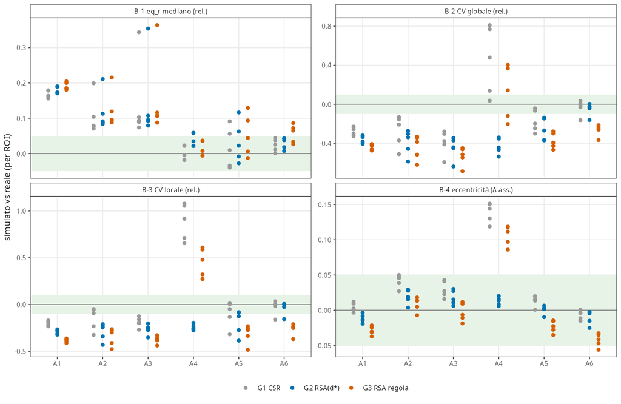

Check B per ROI: scarto simulato vs reale; banda verde = tolleranza pre-registrata.

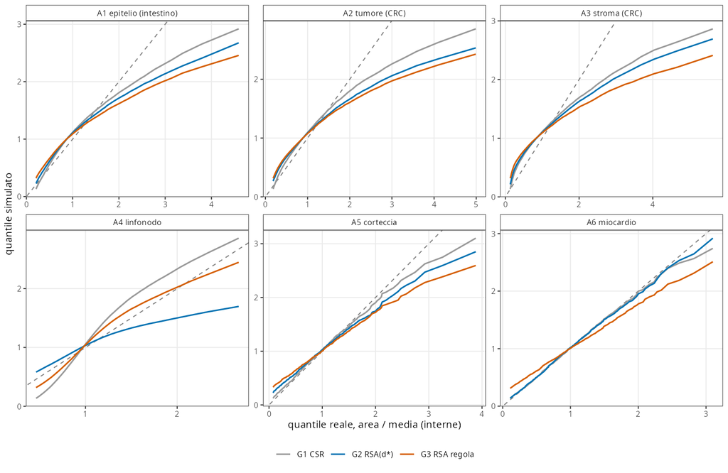

QQ-plot delle aree normalizzate (interne, replica 1, 5 ROI in pool) contro il reale ricalcolato dal pacchetto.

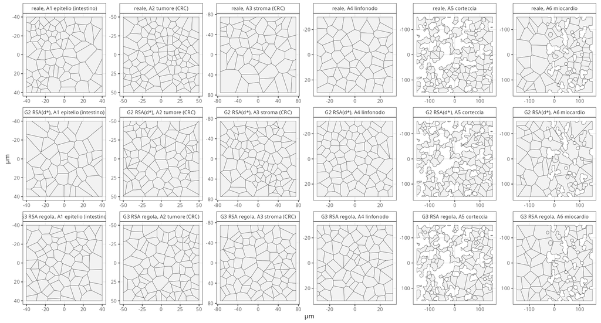

Territori su un ritaglio centrale del ROI r1/f1: reale, G2, G3 (stessa maschera).

```r
k(rd("S1.3_checkB_ks_nsides.csv"), 3)
```

| archetype | model | D_real_sim | D_noise | mean_nsides_real | mean_nsides_sim | var_nsides_real | var_nsides_sim |
| --- | --- | --- | --- | --- | --- | --- | --- |
| A1 | CSR | 0.103 | 0.004 | 5.913 | 5.923 | 1.582 | 1.741 |
| A1 | RSA | 0.133 | 0.006 | 5.913 | 5.934 | 1.582 | 1.546 |
| A1 | RSArule | 0.176 | 0.003 | 5.913 | 5.938 | 1.582 | 1.392 |
| A2 | CSR | 0.104 | 0.007 | 5.958 | 5.960 | 1.339 | 1.771 |
| A2 | RSA | 0.163 | 0.004 | 5.958 | 5.965 | 1.339 | 1.500 |
| A2 | RSArule | 0.191 | 0.005 | 5.958 | 5.968 | 1.339 | 1.370 |
| A3 | CSR | 0.179 | 0.008 | 5.976 | 5.975 | 1.414 | 1.784 |
| A3 | RSA | 0.214 | 0.005 | 5.976 | 5.981 | 1.414 | 1.597 |
| A3 | RSArule | 0.274 | 0.007 | 5.976 | 5.979 | 1.414 | 1.403 |
| A4 | CSR | 0.195 | 0.003 | 5.992 | 5.990 | 0.864 | 1.774 |
| A4 | RSA | 0.117 | 0.002 | 5.992 | 5.996 | 0.864 | 0.852 |
| A4 | RSArule | 0.110 | 0.002 | 5.992 | 5.993 | 0.864 | 1.400 |
| A5 | CSR | 0.041 | 0.021 | 5.823 | 5.847 | 1.445 | 1.836 |
| A5 | RSA | 0.083 | 0.018 | 5.823 | 5.873 | 1.445 | 1.564 |
| A5 | RSArule | 0.134 | 0.044 | 5.823 | 5.889 | 1.445 | 1.352 |
| A6 | CSR | 0.018 | 0.018 | 5.859 | 5.859 | 1.692 | 1.681 |
| A6 | RSA | 0.026 | 0.022 | 5.859 | 5.864 | 1.692 | 1.728 |
| A6 | RSArule | 0.102 | 0.018 | 5.859 | 5.890 | 1.692 | 1.396 |

```r
sens <- V[V$section == "Bsens", ]; cat(sprintf("Sensibilita' (riferimento ricalcolato dal pacchetto con la regola dei frammenti): verdetti identici in %d/%d righe\n", sum(sens$confirmed == "TRUE"), nrow(sens)))
```

```
Sensibilita' (riferimento ricalcolato dal pacchetto con la regola dei frammenti): verdetti identici in 48/48 righe
```

# 4. Controprova

```r
k(V[V$section %in% c("CP", "D"), c("id", "model", "metric", "value", "threshold", "outcome", "prediction", "confirmed")])
```

| id | model | metric | value | threshold | outcome | prediction | confirmed |
| --- | --- | --- | --- | --- | --- | --- | --- |
| CP-1 | testo del design | frazione regioni (3<=n<=1000) scoperte > 1 % | 0.937 (n=300); mediana 0.0943 | >= 0.5 | PASS | PASS | TRUE |
| CP-1 | D-S1.3.1 | regioni scoperte > 1e-9 | 0 | 0 | PASS | PASS | TRUE |
| CP-2 | RSA affine | eccentricita’ monotona in k | 0.770 / 0.767 / 0.768 / 0.772 / 0.771 | monotona | FAIL | PASS | FALSE |
| CP-2 | RSA affine | k minimo con Δ >= 0.05 | Inf | <= 1.5 | FAIL | PASS | FALSE |
| CP-2b (post hoc) | RSA regolare affine | eccentricita’ mediana per k | 0.624 / 0.630 / 0.646 / 0.681 / 0.717 | monotona | PASS | PASS | TRUE |
| CP-2b (post hoc) | RSA regolare affine | k minimo con Δ >= 0.05 | 2 | <= 1.5 | FAIL | PASS | FALSE |
| CP-3 | Chaikin senza contenimento | coppie sovrapposte (ROI con > 0) | 0 (0/30) | > 0 | FAIL | PASS | FALSE |
| CP-3 | Chaikin senza contenimento | coppie senza territorio ritagliato non convesso | 0 | 0 | PASS | PASS | NA |
| CP-3 (dopo la revisione) | Chaikin senza contenimento | territori non contenuti nella regione; area fuori (µm²) | 9521 (29/30 ROI); 9531.2 | descrittivo | INFO | NA | NA |
| CP-3 (dopo la revisione) | D-S1.3.3 | territori smussati non contenuti; riparazioni; pezzi scartati | 0; 24; 150 | 0; info; info | PASS | NA | NA |
| CP-3 | D-S1.3.3 | coppie sovrapposte con contenimento | 0 | 0 | PASS | PASS | TRUE |
| D-1 | RSA regola | area fascia regione 2 / regione 1 (mediana 20 seed) | 1.071 | >= 1.1 (previsione) | INFO | >= 1.1 | FALSE |
| D-3 | - | frazione ritagliate: Spearman con log area regione | -0.78 | descrittivo | INFO | NA | NA |

## CP-1 — il testo del design §5.3 lascia buchi? (confermata)

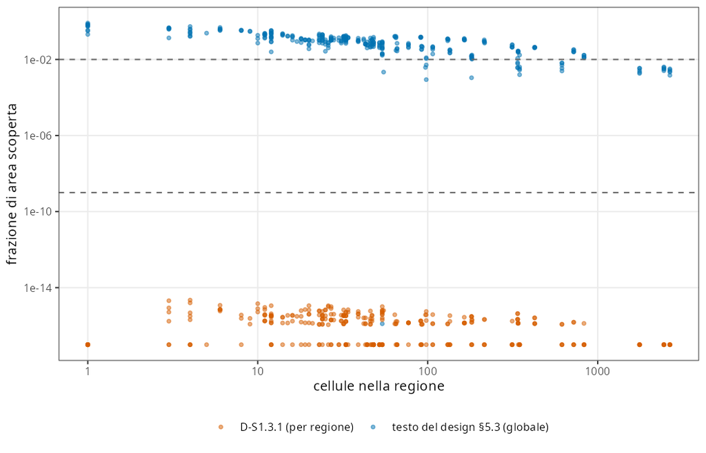

CP-1: frazione di area scoperta per regione, testo del design vs D-S1.3.1 (I1–I5, 5 seed).

## CP-2 — potenza del check di forma (smentita; post hoc CP-2b)

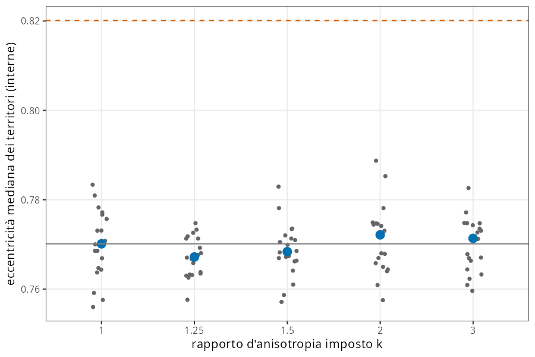

CP-2: eccentricità mediana in funzione dell’anisotropia imposta k (semina RSA d* = 2.5 µm).

CP-2 era mal costruito. Alla densità di A6, con d* = 2.5 µm e una spaziatura di circa 32 µm, la semina è quasi un processo di Poisson, e una trasformazione affine di un processo di Poisson resta Poisson isotropo: l’eccentricità resta 0.767–0.772 per k = 1…3. Con una semina regolare (CP-2b, η = 0.4, post hoc) l’eccentricità cresce in modo monotono (0.624 → 0.717), ma supera Δ = 0.05 solo da k = 2.

L’eccentricità del territorio è quindi una misura di forma debole (BL-073).

## CP-3 — smussatura

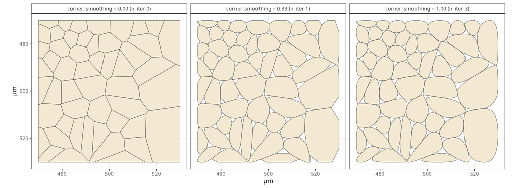

Smussatura di Chaikin su un ritaglio A1 (cs = 0, 1/3, 1).

- **Senza contenimento:** nessuna sovrapposizione fra territori in nessuno dei 30 ROI (previsione smentita; la seconda previsione non è valutabile, perché non ci sono coppie). Misurato dopo la revisione: 9 521 territori smussati escono dalla regione (29/30 ROI, 9 531 µm²). Il difetto di M4 è l’uscita dalla regione, intercettata da C-7 nei test.
- **Con contenimento:** 0 territori fuori dalla regione, 0 sovrapposizioni; 24 anelli di Chaikin riparati e 150 pezzi scartati (parti spezzate dalla smussatura), ora contati.
- **Lacune a cs = 1:** 6.3–8.5 % dell’area per ROI, quasi indipendenti dal tessuto. Descrittivo, senza riferimento biologico.

## Descrittivi

- **D-1 (BL-056).** Rapporto fra le aree dei territori al confine fra due regioni, seconda piazzata / prima: mediana 1.071 (min 0.85, max 1.32; 20 seed). Il valore previsto ≥ 1.1 è smentito.
- **D-3.** La frazione di celle ritagliate cala con l’area della regione (Spearman −0.78).

# Verdetto

**Chiusa con riserve, in deroga.** La regola dell’addendum (punto 4) prescriveva «non chiusa». Luca ha deciso di chiudere scegliendo GEOS, dopo aver visto risultati e revisione.

Riserve:

1. C-5 e C-6 FAIL per l’errore di pre-registrazione descritto in §2 (BL-074).
2. Le operazioni di sovrapposizione GEOS sono inaffidabili su questi territori, perché i vertici condivisi non sono annodati. Va gestito prima dello Step 2 (BL-069), e i check di partizione vanno misurati con predicati o copertura per punti (BL-070).
3. I riferimenti R3 sono calcolati con un’altra regola dei frammenti (BL-071).
4. Il check di forma è debole (BL-073; BL-064 resta aperta).
5. Prestazioni del ritaglio su maschere a gradini di pixel: 0.8–39 s per ROI (BL-072).
6. CV delle aree fuori tolleranza in A1–A5 per la semina omogenea (BL-051/068); la regola di default fallisce anche A6 (BL-050).

# Revisione avversariale

Due revisori indipendenti (sotto-agenti senza accesso alla conversazione), sul commit `37e68ad`. Uscite in `results/S1.3/review/{code,claims}/`.

- **Revisore del codice (15 rilievi).** Reimplementazione in Python (tile Qhull + Sutherland–Hodgman, senza GEOS): 62 121 celle non coinvolte nei frammenti, in 12 casi, identiche entro 5.3e-13. Il caso C-2 A3 r3 è verificato in aritmetica razionale.
  - Bug: contatti puntiformi trattati come confine (RA-code-04), regola dell’arbitro non certificata (RA-code-08).
  - Discrepanze: smussatura che scarta parti e ripara senza contare (06/07); agganci quasi mai riparatori (05); design §5.3 non aggiornato (15).
  - Metodo: catene di orfani dipendenti dall’ordine (03); vertici non annodati (11); check senza potenza (12).
- **Revisore delle affermazioni (21 rilievi).** Ricalcolo indipendente dei 188 verdetti: 188/188 con lo stesso esito, 187/188 identici in tutti i campi (l’unica differenza è l’annotazione «vacua» del revisore sulla riga CP-3 n.2, accolta: RA-claims-10). Rilievi principali:
  - la deroga alla regola non era dichiarata (RA-claims-02);
  - «31 volte» era sbagliato, il valore giusto è 131 (05);
  - il riassunto del check B e CP-3 erano sopra-interpretati (08/09);
  - le previsioni di G1 non erano codificate (07);
  - l’attribuzione di C-6 era inferita (11);
  - tre numeri non stavano in nessun file (15);
  - era citato il commit sbagliato (19).

```r
ra <- rbind(data.frame(revisore = "codice", read.csv(file.path(RES, "review/code/findings.csv"), check.names = FALSE)),
            data.frame(revisore = "affermazioni", read.csv(file.path(RES, "review/claims/findings.csv"), check.names = FALSE)))
k(as.data.frame(table(revisore = ra$revisore, gravita = ra[[3]])))
```

| revisore | gravita | Freq |
| --- | --- | --- |
| affermazioni | bug | 0 |
| codice | bug | 2 |
| affermazioni | confermato | 3 |
| codice | confermato | 5 |
| affermazioni | discrepanza | 8 |
| codice | discrepanza | 5 |
| affermazioni | metodo | 10 |
| codice | metodo | 3 |

```r
k(rd("S1.3_review_actions.csv"))
```

[output not shown]

# Riproducibilità

Run pre-revisione: commit `72126a5`; analisi pre-revisione: `37e68ad`; codice finale e riesecuzione: `26baaf0`; risultati, report e documenti: commit di chiusura.

```bash
cd ~/2025.geo_spatialtrans
bash R/testing/run_S1.3.sh      # check C, 7 mutanti, ROI, CP, prestazioni, analisi (~5 h; deldir 449 536 punti ~78 min)
Rscript --vanilla tools/S1.3_review_checks.R /mnt/micron/geo_spatialtrans/S1.3_prereview     # controlli chiesti dalla revisione
Rscript --vanilla tools/S1.3_c2_coverage.R && Rscript --vanilla tools/S1.3_c2_pairs_check.R && Rscript --vanilla tools/S1.3_analysis.R
Rscript --vanilla tools/S1.3_figures.R && quarto render reports/S1.3.qmd
```